# Exercise 2

2022-05-05

Task 1: Import Data & Install Libraries

```r
## Load the necessary libraries ################################################

library(readr)        # to import tabular data (e.g. csv)
library(dplyr)        # to manipulate (tabular) data
```

```r
library(ggplot2)      # to visualize data
library(sf)           # to handle spatial vector data
library(terra)        # To handle raster data
library(lubridate)    # To handle dates and times
library(tidyverse)
## Import the downloaded csv ##################################################

wildschwein_BE <- read_delim("wildschwein_BE_2056.csv",",") # adjust path
wildschwein_BE
```

```
## # A tibble: 51,246 × 6
##    TierID TierName CollarID DatetimeUTC                E        N
##    <chr>  <chr>       <dbl> <dttm>                 <dbl>    <dbl>
##  1 002A   Sabi        12275 2014-08-22 21:00:12 2570409. 1204752.
##  2 002A   Sabi        12275 2014-08-22 21:15:16 2570402. 1204863.
##  3 002A   Sabi        12275 2014-08-22 21:30:43 2570394. 1204826.
##  4 002A   Sabi        12275 2014-08-22 21:46:07 2570379. 1204817.
##  5 002A   Sabi        12275 2014-08-22 22:00:22 2570390. 1204818.
##  6 002A   Sabi        12275 2014-08-22 22:15:10 2570390. 1204825.
##  7 002A   Sabi        12275 2014-08-22 22:30:13 2570387. 1204831.
##  8 002A   Sabi        12275 2014-08-22 22:45:11 2570381. 1204840.
##  9 002A   Sabi        12275 2014-08-22 23:00:27 2570316. 1204935.
## 10 002A   Sabi        12275 2014-08-22 23:15:41 2570393. 1204815.
## # … with 51,236 more rows
```

```r
wildschwein_BE <- st_as_sf(wildschwein_BE, coords = c("E", "N"), crs = 2056, remove = FALSE)

wildschwein_BE$timelag <- as.numeric(difftime(lead(wildschwein_BE$DatetimeUTC), wildschwein_BE$DatetimeUTC, units = "secs"))

wildschwein_BE
```

```
## Simple feature collection with 51246 features and 7 fields
## Geometry type: POINT
## Dimension:     XY
## Bounding box:  xmin: 2568153 ymin: 1202306 xmax: 2575154 ymax: 1207609
## Projected CRS: CH1903+ / LV95
## # A tibble: 51,246 × 8
##    TierID TierName CollarID DatetimeUTC                E        N
##  * <chr>  <chr>       <dbl> <dttm>                 <dbl>    <dbl>
##  1 002A   Sabi        12275 2014-08-22 21:00:12 2570409. 1204752.
##  2 002A   Sabi        12275 2014-08-22 21:15:16 2570402. 1204863.
##  3 002A   Sabi        12275 2014-08-22 21:30:43 2570394. 1204826.
##  4 002A   Sabi        12275 2014-08-22 21:46:07 2570379. 1204817.
##  5 002A   Sabi        12275 2014-08-22 22:00:22 2570390. 1204818.
##  6 002A   Sabi        12275 2014-08-22 22:15:10 2570390. 1204825.
##  7 002A   Sabi        12275 2014-08-22 22:30:13 2570387. 1204831.
##  8 002A   Sabi        12275 2014-08-22 22:45:11 2570381. 1204840.
##  9 002A   Sabi        12275 2014-08-22 23:00:27 2570316. 1204935.
## 10 002A   Sabi        12275 2014-08-22 23:15:41 2570393. 1204815.
## # … with 51,236 more rows, and 2 more variables: geometry <POINT [m]>,
## #   timelag <dbl>
```

Task 2: Getting an overview

How many individuals were tracked?

```r
unique(wildschwein_BE$TierID)
```

```
## [1] "002A" "016A" "018A"
```

```r
unique(wildschwein_BE$TierName)
```

```
## [1] "Sabi" "Rosa" "Ruth"
```

…3 Individuals

Visual approach:

For how long were the individuals tracked? Are there gaps?

```r
wildschwein_dates <- wildschwein_BE %>%
  group_by(TierID) %>%
  summarise(
    startTime = min(DatetimeUTC),
    endTime = max(DatetimeUTC),
    duration = as.factor(as.integer(difftime(endTime, startTime, units = "days")))
  )
wildschwein_dates
```

```
## Simple feature collection with 3 features and 4 fields
## Geometry type: MULTIPOINT
## Dimension:     XY
## Bounding box:  xmin: 2568153 ymin: 1202306 xmax: 2575154 ymax: 1207609
## Projected CRS: CH1903+ / LV95
## # A tibble: 3 × 5
##   TierID startTime           endTime             duration
##   <chr>  <dttm>              <dttm>              <fct>
## 1 002A   2014-08-22 21:00:12 2015-07-27 11:00:14 338
## 2 016A   2014-11-07 07:45:44 2015-06-29 23:45:11 234
## 3 018A   2014-11-07 18:00:43 2015-07-27 09:45:15 261
## # … with 1 more variable: geometry <MULTIPOINT [m]>
```

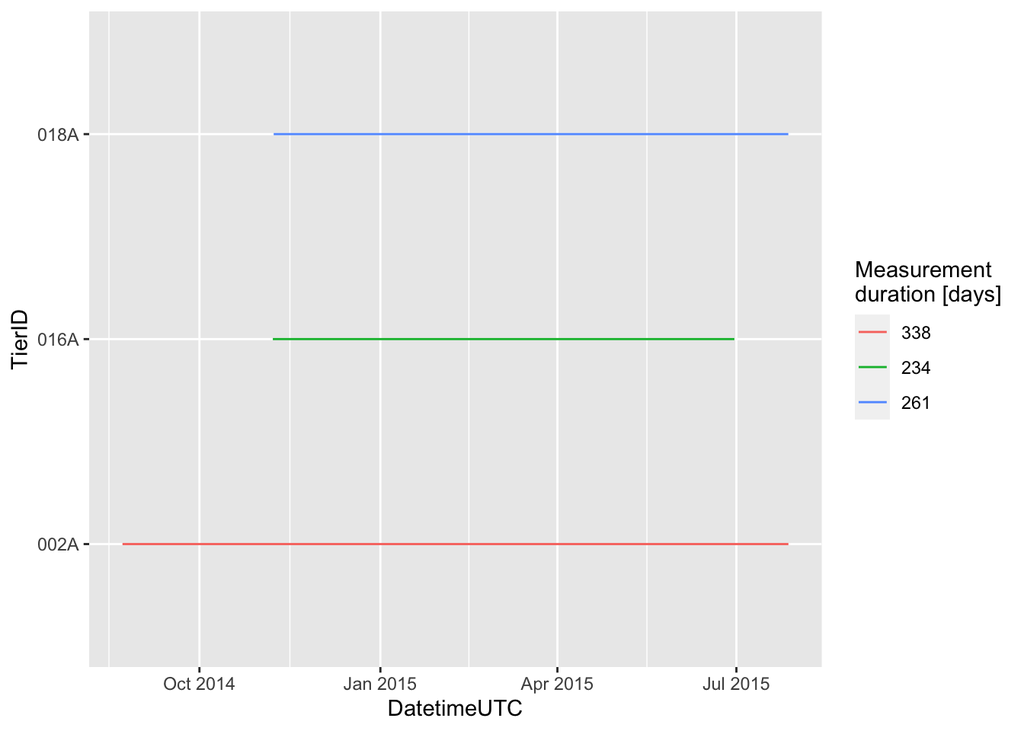

```r
wildschwein_dates %>%
  ggplot(aes(color = duration)) +
  geom_segment(aes(x = startTime, xend = endTime, y = TierID, yend = TierID), size = 0.5) +
  xlab("DatetimeUTC") +
  labs(color='Measurement \nduration [days]')
```

Were all individuals tracked concurrently or sequentially? Interpretation: All the animals were measured concurrently at least at point

What is the temporal sampling interval between the locations? => What does that mean?

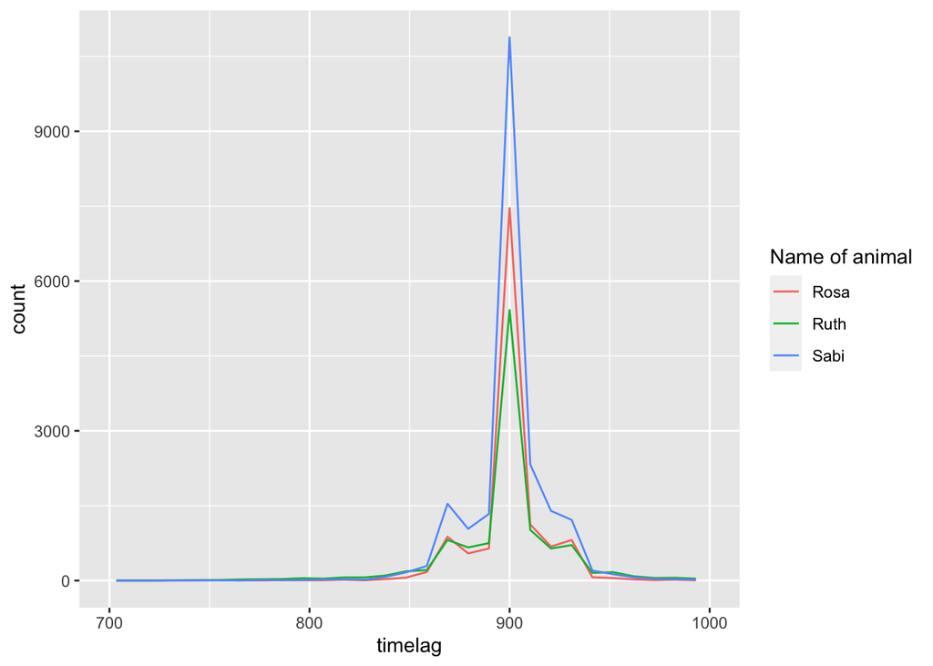

```r
wildschwein_BE %>%
  ggplot() +
  geom_freqpoly(mapping = aes(x = timelag, colour = TierName)) +
  xlim(c(700, 1000)) +
  labs(color='Name of animal')
```

Interpretation: I show that the large majority of timelags (for all three individuals) was somewhere between 850 and 950 seconds

Task 3: Deriving movement parameters I: Speed

```r
wildschwein_BE$steplength <-
  ((lead(wildschwein_BE$E, 1) - wildschwein_BE$E)^2 + (lead(wildschwein_BE$N, 1) - wildschwein_BE$N)^2)^(1/2)
wildschwein_BE
```

```
## Simple feature collection with 51246 features and 8 fields
## Geometry type: POINT
## Dimension:     XY
## Bounding box:  xmin: 2568153 ymin: 1202306 xmax: 2575154 ymax: 1207609
## Projected CRS: CH1903+ / LV95
## # A tibble: 51,246 × 9
##    TierID TierName CollarID DatetimeUTC                E        N
##  * <chr>  <chr>       <dbl> <dttm>                 <dbl>    <dbl>
##  1 002A   Sabi        12275 2014-08-22 21:00:12 2570409. 1204752.
##  2 002A   Sabi        12275 2014-08-22 21:15:16 2570402. 1204863.
##  3 002A   Sabi        12275 2014-08-22 21:30:43 2570394. 1204826.
##  4 002A   Sabi        12275 2014-08-22 21:46:07 2570379. 1204817.
##  5 002A   Sabi        12275 2014-08-22 22:00:22 2570390. 1204818.
##  6 002A   Sabi        12275 2014-08-22 22:15:10 2570390. 1204825.
##  7 002A   Sabi        12275 2014-08-22 22:30:13 2570387. 1204831.
##  8 002A   Sabi        12275 2014-08-22 22:45:11 2570381. 1204840.
##  9 002A   Sabi        12275 2014-08-22 23:00:27 2570316. 1204935.
## 10 002A   Sabi        12275 2014-08-22 23:15:41 2570393. 1204815.
## # … with 51,236 more rows, and 3 more variables: geometry <POINT [m]>,
## #   timelag <dbl>, steplength <dbl>
```

```r
wildschwein_BE$speed <- wildschwein_BE$steplength / wildschwein_BE$timelag
wildschwein_BE
```

```
## Simple feature collection with 51246 features and 9 fields
## Geometry type: POINT
## Dimension:     XY
## Bounding box:  xmin: 2568153 ymin: 1202306 xmax: 2575154 ymax: 1207609
## Projected CRS: CH1903+ / LV95
## # A tibble: 51,246 × 10
##    TierID TierName CollarID DatetimeUTC                E        N
##  * <chr>  <chr>       <dbl> <dttm>                 <dbl>    <dbl>
##  1 002A   Sabi        12275 2014-08-22 21:00:12 2570409. 1204752.
##  2 002A   Sabi        12275 2014-08-22 21:15:16 2570402. 1204863.
##  3 002A   Sabi        12275 2014-08-22 21:30:43 2570394. 1204826.
##  4 002A   Sabi        12275 2014-08-22 21:46:07 2570379. 1204817.
##  5 002A   Sabi        12275 2014-08-22 22:00:22 2570390. 1204818.
##  6 002A   Sabi        12275 2014-08-22 22:15:10 2570390. 1204825.
##  7 002A   Sabi        12275 2014-08-22 22:30:13 2570387. 1204831.
##  8 002A   Sabi        12275 2014-08-22 22:45:11 2570381. 1204840.
##  9 002A   Sabi        12275 2014-08-22 23:00:27 2570316. 1204935.
## 10 002A   Sabi        12275 2014-08-22 23:15:41 2570393. 1204815.
## # … with 51,236 more rows, and 4 more variables: geometry <POINT [m]>,
## #   timelag <dbl>, steplength <dbl>, speed <dbl>
```

What speed unit do you get?

Speed = Steplength per second => But what is steplength? => Apparently it’s meter (see Task 4, last plot) As such, speed = m/s

Task 4: Cross-scale movement analysis

```r
caro <- read_delim("caro60.csv")
caro
```

```
## # A tibble: 200 × 6
##    TierID TierName CollarID DatetimeUTC                E        N
##    <chr>  <chr>       <dbl> <dttm>                 <dbl>    <dbl>
##  1 010C   Caro        13973 2015-09-15 08:07:00 2570589. 1205095.
##  2 010C   Caro        13973 2015-09-15 08:08:00 2570573. 1205096.
##  3 010C   Caro        13973 2015-09-15 08:09:00 2570536. 1205099.
##  4 010C   Caro        13973 2015-09-15 08:10:00 2570518. 1205115.
##  5 010C   Caro        13973 2015-09-15 08:11:00 2570499. 1205130.
##  6 010C   Caro        13973 2015-09-15 08:12:00 2570489. 1205130.
##  7 010C   Caro        13973 2015-09-15 08:13:00 2570482. 1205124.
##  8 010C   Caro        13973 2015-09-15 08:14:00 2570481. 1205108.
##  9 010C   Caro        13973 2015-09-15 08:15:00 2570486. 1205099.
## 10 010C   Caro        13973 2015-09-15 08:16:00 2570490. 1205100.
## # … with 190 more rows
```

```r
caro <- st_as_sf(caro, coords = c("E", "N"), crs = 2056, remove = FALSE)
caro
```

```
## Simple feature collection with 200 features and 6 fields
## Geometry type: POINT
## Dimension:     XY
## Bounding box:  xmin: 2570481 ymin: 1205055 xmax: 2570626 ymax: 1205130
## Projected CRS: CH1903+ / LV95
## # A tibble: 200 × 7
##    TierID TierName CollarID DatetimeUTC                E        N
##  * <chr>  <chr>       <dbl> <dttm>                 <dbl>    <dbl>
##  1 010C   Caro        13973 2015-09-15 08:07:00 2570589. 1205095.
##  2 010C   Caro        13973 2015-09-15 08:08:00 2570573. 1205096.
##  3 010C   Caro        13973 2015-09-15 08:09:00 2570536. 1205099.
##  4 010C   Caro        13973 2015-09-15 08:10:00 2570518. 1205115.
##  5 010C   Caro        13973 2015-09-15 08:11:00 2570499. 1205130.
##  6 010C   Caro        13973 2015-09-15 08:12:00 2570489. 1205130.
##  7 010C   Caro        13973 2015-09-15 08:13:00 2570482. 1205124.
##  8 010C   Caro        13973 2015-09-15 08:14:00 2570481. 1205108.
##  9 010C   Caro        13973 2015-09-15 08:15:00 2570486. 1205099.
## 10 010C   Caro        13973 2015-09-15 08:16:00 2570490. 1205100.
## # … with 190 more rows, and 1 more variable: geometry <POINT [m]>
```

Calculating speed at different intervals:

```r
caro_3 <- caro %>%
  filter(row_number() == 1 | row_number() %% 3 == 0)

caro_6 <- caro %>%
  filter(row_number() == 1 | row_number() %% 6 == 0)

caro_9 <- caro %>%
  filter(row_number() == 1 | row_number() %% 9 == 0)

nrow(caro)
```

```
## [1] 200
```

```r
nrow(caro_3)
```

```
## [1] 67
```

```r
nrow(caro_6)
```

```
## [1] 34
```

```r
nrow(caro_9)
```

```
## [1] 23
```

```r
lead(caro$DatetimeUTC, 1)
```

```
##   [1] "2015-09-15 08:08:00 UTC" "2015-09-15 08:09:00 UTC"
##   [3] "2015-09-15 08:10:00 UTC" "2015-09-15 08:11:00 UTC"
##   [5] "2015-09-15 08:12:00 UTC" "2015-09-15 08:13:00 UTC"
##   [7] "2015-09-15 08:14:00 UTC" "2015-09-15 08:15:00 UTC"
##   [9] "2015-09-15 08:16:00 UTC" "2015-09-15 08:17:00 UTC"
##  [11] "2015-09-15 08:18:00 UTC" "2015-09-15 08:19:00 UTC"
##  [13] "2015-09-15 08:20:00 UTC" "2015-09-15 08:21:00 UTC"
##  [15] "2015-09-15 08:22:00 UTC" "2015-09-15 08:23:00 UTC"
##  [17] "2015-09-15 08:24:00 UTC" "2015-09-15 08:25:00 UTC"
##  [19] "2015-09-15 08:26:00 UTC" "2015-09-15 08:27:00 UTC"
##  [21] "2015-09-15 08:28:00 UTC" "2015-09-15 08:29:00 UTC"
##  [23] "2015-09-15 08:30:00 UTC" "2015-09-15 08:31:00 UTC"
##  [25] "2015-09-15 08:32:00 UTC" "2015-09-15 08:33:00 UTC"
##  [27] "2015-09-15 08:34:00 UTC" "2015-09-15 08:35:00 UTC"
##  [29] "2015-09-15 08:36:00 UTC" "2015-09-15 08:37:00 UTC"
```

[output cut: 85 more lines]

(Here’s a little function that does it for you)

```r
calc_step_and_speed <- function(df) {

  df <- mutate(df, timelag = as.numeric(difftime(lead(DatetimeUTC), DatetimeUTC, unit = "secs")))
  df <- mutate(df, steplength = ((lead(E, 1) - E)^2 + (lead(N, 1) - N)^2)^(1/2))
  df <- mutate(df, speed = steplength / timelag)

  return(df)
}

caro <- calc_step_and_speed(caro)
caro
```

```
## Simple feature collection with 200 features and 9 fields
## Geometry type: POINT
## Dimension:     XY
## Bounding box:  xmin: 2570481 ymin: 1205055 xmax: 2570626 ymax: 1205130
## Projected CRS: CH1903+ / LV95
## # A tibble: 200 × 10
##    TierID TierName CollarID DatetimeUTC                E        N
##  * <chr>  <chr>       <dbl> <dttm>                 <dbl>    <dbl>
##  1 010C   Caro        13973 2015-09-15 08:07:00 2570589. 1205095.
##  2 010C   Caro        13973 2015-09-15 08:08:00 2570573. 1205096.
##  3 010C   Caro        13973 2015-09-15 08:09:00 2570536. 1205099.
##  4 010C   Caro        13973 2015-09-15 08:10:00 2570518. 1205115.
##  5 010C   Caro        13973 2015-09-15 08:11:00 2570499. 1205130.
##  6 010C   Caro        13973 2015-09-15 08:12:00 2570489. 1205130.
##  7 010C   Caro        13973 2015-09-15 08:13:00 2570482. 1205124.
##  8 010C   Caro        13973 2015-09-15 08:14:00 2570481. 1205108.
##  9 010C   Caro        13973 2015-09-15 08:15:00 2570486. 1205099.
## 10 010C   Caro        13973 2015-09-15 08:16:00 2570490. 1205100.
## # … with 190 more rows, and 4 more variables: geometry <POINT [m]>,
## #   timelag <dbl>, steplength <dbl>, speed <dbl>
```

```r
caro_3 <- calc_step_and_speed(caro_3)
caro_3
```

```
## Simple feature collection with 67 features and 9 fields
## Geometry type: POINT
## Dimension:     XY
## Bounding box:  xmin: 2570486 ymin: 1205056 xmax: 2570625 ymax: 1205130
## Projected CRS: CH1903+ / LV95
## # A tibble: 67 × 10
##    TierID TierName CollarID DatetimeUTC                E        N
##  * <chr>  <chr>       <dbl> <dttm>                 <dbl>    <dbl>
##  1 010C   Caro        13973 2015-09-15 08:07:00 2570589. 1205095.
##  2 010C   Caro        13973 2015-09-15 08:09:00 2570536. 1205099.
##  3 010C   Caro        13973 2015-09-15 08:12:00 2570489. 1205130.
##  4 010C   Caro        13973 2015-09-15 08:15:00 2570486. 1205099.
##  5 010C   Caro        13973 2015-09-15 08:18:00 2570499. 1205089.
##  6 010C   Caro        13973 2015-09-15 08:21:00 2570499. 1205089.
##  7 010C   Caro        13973 2015-09-15 08:24:00 2570500. 1205092.
##  8 010C   Caro        13973 2015-09-15 08:27:00 2570499. 1205089.
##  9 010C   Caro        13973 2015-09-15 08:30:00 2570497. 1205091.
## 10 010C   Caro        13973 2015-09-15 08:33:00 2570499. 1205089.
## # … with 57 more rows, and 4 more variables: geometry <POINT [m]>,
## #   timelag <dbl>, steplength <dbl>, speed <dbl>
```

```r
caro_6 <- calc_step_and_speed(caro_6)
caro_6
```

```
## Simple feature collection with 34 features and 9 fields
## Geometry type: POINT
## Dimension:     XY
## Bounding box:  xmin: 2570489 ymin: 1205056 xmax: 2570623 ymax: 1205130
## Projected CRS: CH1903+ / LV95
## # A tibble: 34 × 10
##    TierID TierName CollarID DatetimeUTC                E        N
##  * <chr>  <chr>       <dbl> <dttm>                 <dbl>    <dbl>
##  1 010C   Caro        13973 2015-09-15 08:07:00 2570589. 1205095.
##  2 010C   Caro        13973 2015-09-15 08:12:00 2570489. 1205130.
##  3 010C   Caro        13973 2015-09-15 08:18:00 2570499. 1205089.
##  4 010C   Caro        13973 2015-09-15 08:24:00 2570500. 1205092.
##  5 010C   Caro        13973 2015-09-15 08:30:00 2570497. 1205091.
##  6 010C   Caro        13973 2015-09-15 08:36:00 2570496. 1205089.
##  7 010C   Caro        13973 2015-09-15 08:42:00 2570492. 1205090.
##  8 010C   Caro        13973 2015-09-15 08:48:00 2570499. 1205089.
##  9 010C   Caro        13973 2015-09-15 08:54:00 2570496. 1205088.
## 10 010C   Caro        13973 2015-09-15 09:00:00 2570500. 1205094.
## # … with 24 more rows, and 4 more variables: geometry <POINT [m]>,
## #   timelag <dbl>, steplength <dbl>, speed <dbl>
```

```r
caro_9 <- calc_step_and_speed(caro_9)
caro_9
```

```
## Simple feature collection with 23 features and 9 fields
## Geometry type: POINT
## Dimension:     XY
## Bounding box:  xmin: 2570486 ymin: 1205056 xmax: 2570623 ymax: 1205100
## Projected CRS: CH1903+ / LV95
## # A tibble: 23 × 10
##    TierID TierName CollarID DatetimeUTC                E        N
##  * <chr>  <chr>       <dbl> <dttm>                 <dbl>    <dbl>
##  1 010C   Caro        13973 2015-09-15 08:07:00 2570589. 1205095.
##  2 010C   Caro        13973 2015-09-15 08:15:00 2570486. 1205099.
##  3 010C   Caro        13973 2015-09-15 08:24:00 2570500. 1205092.
##  4 010C   Caro        13973 2015-09-15 08:33:00 2570499. 1205089.
##  5 010C   Caro        13973 2015-09-15 08:42:00 2570492. 1205090.
##  6 010C   Caro        13973 2015-09-15 08:51:00 2570497. 1205090.
##  7 010C   Caro        13973 2015-09-15 09:00:00 2570500. 1205094.
##  8 010C   Caro        13973 2015-09-15 09:09:00 2570498. 1205094.
##  9 010C   Caro        13973 2015-09-15 09:18:00 2570623. 1205075.
## 10 010C   Caro        13973 2015-09-15 09:27:00 2570598. 1205086.
## # … with 13 more rows, and 4 more variables: geometry <POINT [m]>,
## #   timelag <dbl>, steplength <dbl>, speed <dbl>
```

Visualizing derived speed at different sampling intervals:

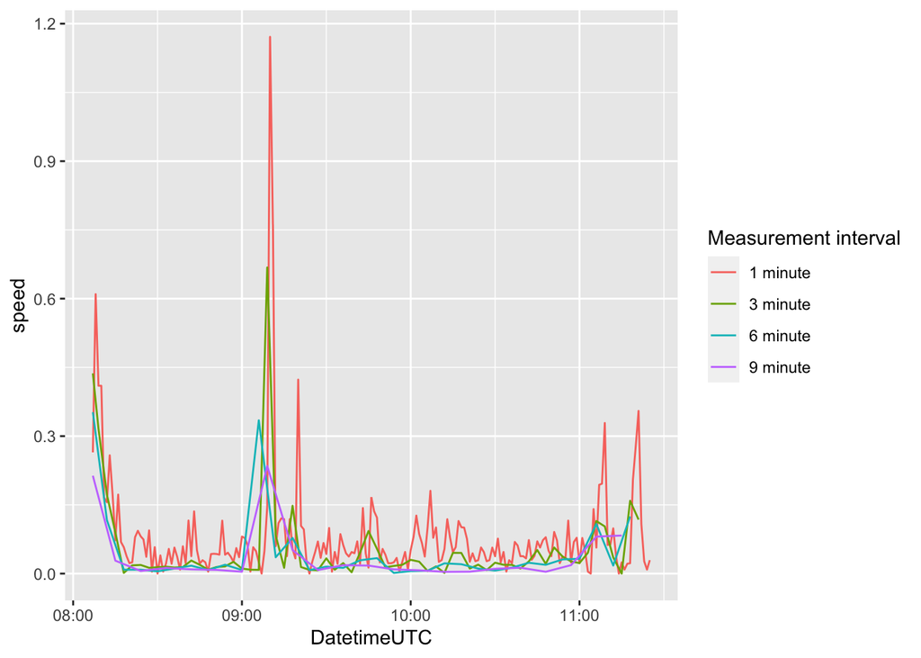

```r
caro_combined <- bind_rows("1 minute" = caro, "3 minute" = caro_3, "6 minute" = caro_6, "9 minute" = caro_9, .id = "groups")

caro_combined <- drop_na(caro_combined, speed)

caro_combined %>%
  ggplot(mapping = aes(x = DatetimeUTC, y = speed, colour = groups)) +
  geom_line() +
  labs(color='Measurement interval')
```

Interpretation: The longer the intervals, the slower the derived speeds and the smaller the values of acceleration and deceleration. In other words: When deriving the sped at a low interval (i.e. 9 minutes), everything becomes a little calmer, the individuals are not speeding up / slowing down as quickly as when deriving the speed at a high interval (i.e. 1 minute)

Visualizing the trajectories:

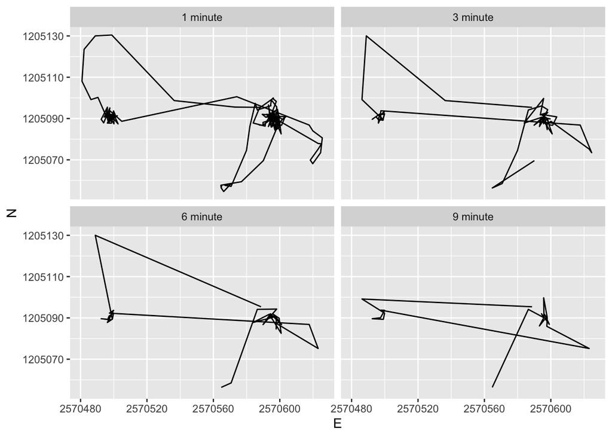

```r
caro_combined %>%
  ggplot() +
  geom_path(mapping = aes(x = E, y = N)) +
  facet_wrap(~ groups, ncol = 2)
```

Interpretation: This graph is not as pretty as the example. However, it shows quickly that the interval at which speed is derived, has a strong effect on the mapping of the trajectories. Namely, the higher the interval (i.e. 1 minute), the rounder the edges and the more precise the trajectory. The lower the interval (i.e. 9 minutes), the sharper the edges and the rougher and less accurate the trajectories.

One more pretty graph:

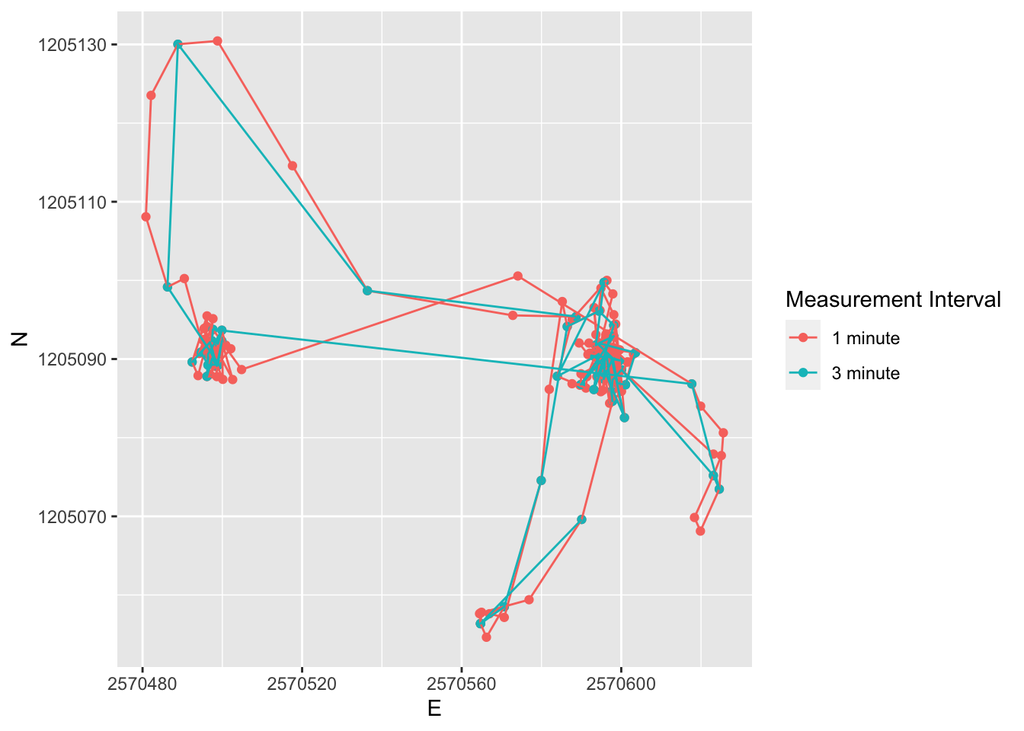

```r
caro_combined %>%
  filter(groups == "1 minute" | groups == "3 minute") %>%
  ggplot(mapping = aes(x = E, y = N, color = groups)) +
  geom_point() +
  geom_path() +
  labs(color='Measurement Interval')
```

Task 5: Deriving movement parameters II: Rolling window functions

```r
library(zoo)
example <- rnorm(10)
example
```

```
##  [1] -0.55996870 -0.01945221 -0.34229404 -1.71097073  0.74223150  0.88981911
##  [7] -1.12638824 -0.63565352 -2.20211640  1.08066780
```

```r
rollmean(example, k = 3, fill = NA, align = "left")
```

```
##  [1] -0.30723832 -0.69090566 -0.43701109 -0.02630671  0.16855412 -0.29074088
##  [7] -1.32138605 -0.58570071          NA          NA
```

```r
rollmean(example, k = 4, fill = NA, align = "left")
```

```
##  [1] -0.65817142 -0.33262137 -0.10530354 -0.30132709 -0.03249779 -0.76858476
##  [7] -0.72087259          NA          NA          NA
```

Plotting and comparing speed with different moving window intervalls:

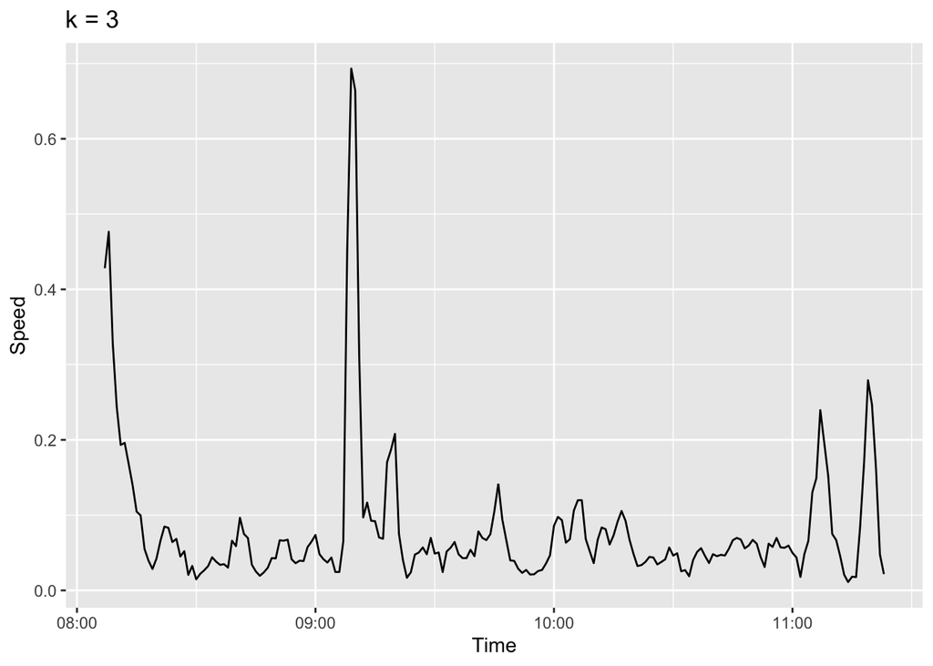

```r
caro$rollmean_3 <- rollmean(caro$speed, k = 3, fill = NA, align = "left")
rm3_plot <- caro %>%
  drop_na(rollmean_3) %>%
  ggplot(mapping = aes(x = DatetimeUTC, y = rollmean_3)) +
  geom_line() +
  labs(y = "Speed", x = "Time", title = "k = 3")
rm3_plot
```

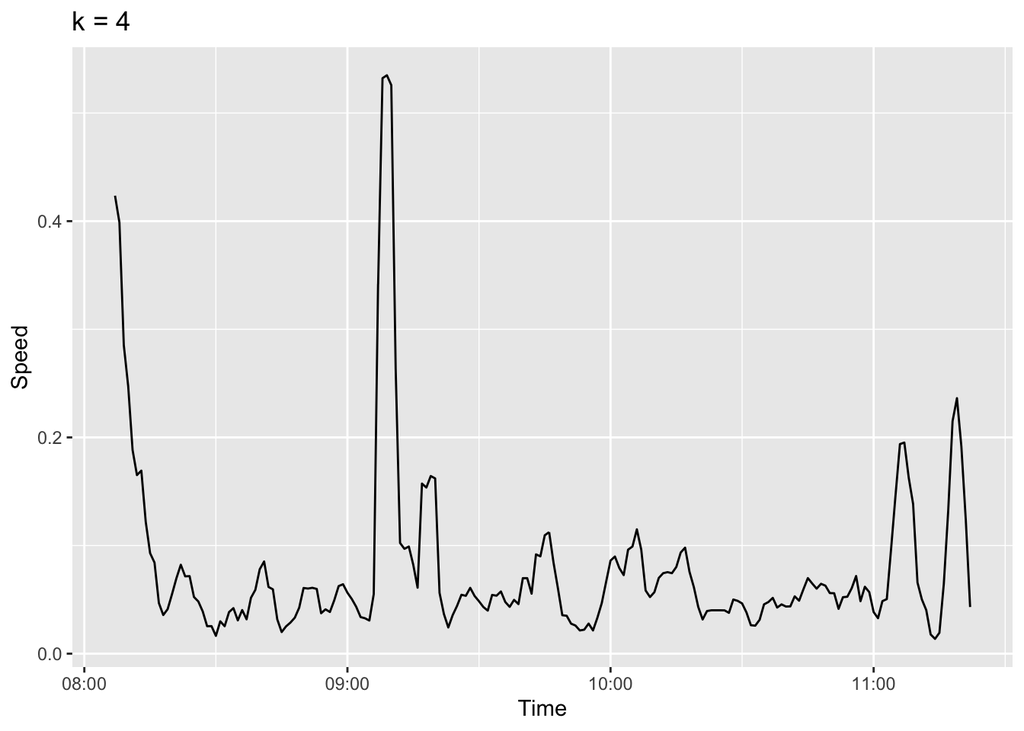

```r
caro$rollmean_4 <- rollmean(caro$speed, k = 4, fill = NA, align = "left")
rm4_plot <- caro %>%
  drop_na(rollmean_4) %>%
  ggplot(mapping = aes(x = DatetimeUTC, y = rollmean_4)) +
  geom_line() +
  labs(y = "Speed", x = "Time", title = "k = 4")
rm4_plot
```

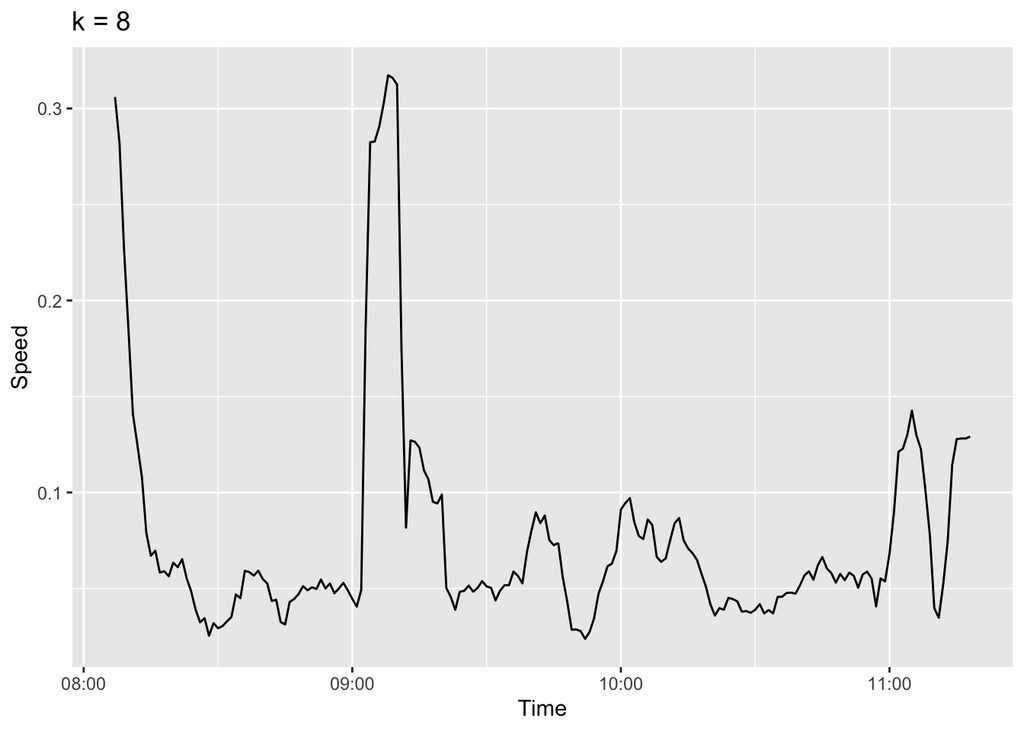

```r
caro$rollmean_8 <- rollmean(caro$speed, k = 8, fill = NA, align = "left")
rm8_plot <- caro %>%
  drop_na(rollmean_8) %>%
  ggplot(mapping = aes(x = DatetimeUTC, y = rollmean_8)) +
  geom_line() +
  labs(y = "Speed", x = "Time", title = "k = 8")
rm8_plot
```

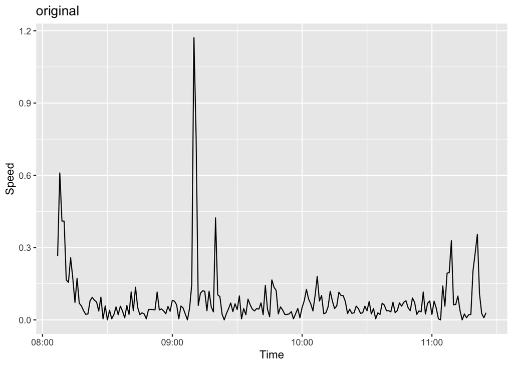

```r
orig_plot <- caro %>%
  drop_na(speed) %>%
  ggplot(mapping = aes(x = DatetimeUTC, y = speed)) +
  geom_line() +
  labs(y = "Speed", x = "Time", title = "original")
orig_plot
```

Showing the derived speeds with different rolling windows all at once:

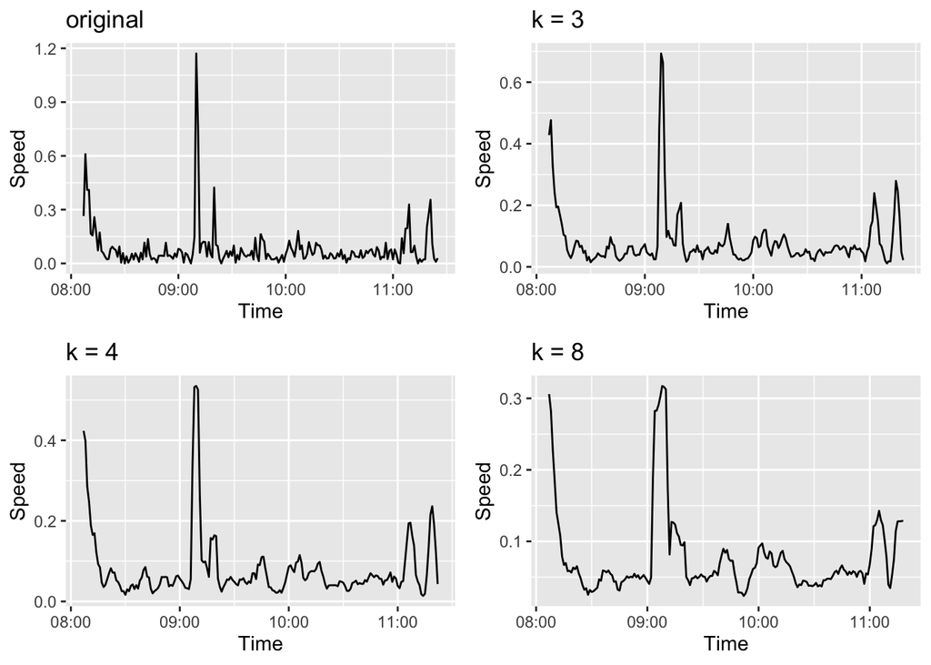

```r
library(cowplot)
plot_grid(orig_plot, rm3_plot, rm4_plot, rm8_plot)
```

Interpretation: The plot shows that the higher the rollmean value (k) (i.e. the larger the moving window), the rounder the curve becomes. The edges become less sharp and we get a smoother curve